# Project #4 - Bank Customers Churn Prediction

Bank Customer Churn Prediction

## Problem Statement

### Context

Businesses like banks which provide service have to worry about problem of **Customer Churn**, i.e. customers leaving and joining another service provider. It is important to understand which aspects of the service influence a customer's decision in this regard. Management can concentrate efforts on improvement of service, keeping in mind these priorities.

### Objective

As a Data Scientist at the bank, your task is to build a neural network-based classifier to predict whether a customer is likely to leave the bank within the next six months.

💡 **This is a binary classification problem that will be solved by training multiple Neural Networks and selecting the best-performing one**.

### Data Dictionary

The case study uses an open-source dataset from Kaggle, consisting of 10,000 samples and 14 features, including `CustomerId`, `CreditScore`, `Geography`, `Gender`, `Age`, `Tenure`, `Balance`, and others.

- **CustomerId**: Unique ID which is assigned to each customer.
- **Surname**: Last name of the customer.
- **CreditScore**: It defines the credit history of the customer.
- **Geography**: A customer’s location.
- **Gender**: It defines the gender of the customer.
- **Age**: Age of the customer.
- **Tenure**: Number of years for which the customer has been with the bank.
- **NumOfProducts**: Refers to the number of products that a customer has purchased through the bank.
- **Balance**: Current account balance.
- **HasCrCard**: It is a categorical variable which indicates whether the customer has credit card or not.
- **EstimatedSalary**: Estimated salary of the customer.
- **isActiveMember**: It is a categorical variable that indicates whether the customer is an active member of the bank, meaning they regularly use bank products, make transactions, and engage with the bank's services.
- **Exited**: This variable indicates whether the customer left the bank within six months. It has two possible values: `0`: No (The customer did not leave the bank) or `1`: Yes (The customer left the bank).

## Importing Necessary Libraries

```python
# Installing the necessary libraries with the specified version
!pip install tensorflow==2.17.0 scikit-learn==1.3.1 seaborn==0.13.1 matplotlib==3.8.0 numpy==1.25.0 pandas==2.2.2 -q --user --no-warn-script-location
```

**Note**: After executing the above cell, restart the notebook kernel and rerun all steps from the beginning.

```python
import pandas as pd   # Library for data manipulation and analysis, especially with tabular data
import numpy as np   # Fundamental package for numerical computations and handling multidimensional arrays
import matplotlib.pyplot as plt   # Comprehensive library for creating static, animated, and interactive visualizations
import seaborn as sns   # Statistical data visualization library built on matplotlib, offering advanced and aesthetically pleasing plots
import time   # Module for handling time-related tasks, such as measuring execution time or adding delays

# For splitting datasets into training and testing sets
from sklearn.model_selection import train_test_split
# Tools for encoding categorical variables, scaling features, and other data preprocessing tasks
from sklearn.preprocessing import LabelEncoder, OneHotEncoder, StandardScaler
# For handling missing data by imputing appropriate values
from sklearn.impute import SimpleImputer
# Functions for evaluating machine learning model performance
from sklearn.metrics import confusion_matrix, f1_score, accuracy_score, recall_score, precision_score, classification_report, roc_curve

import tensorflow as tf   # Open-source platform for machine learning and deep learning
from tensorflow import keras   # High-level API for building and training deep learning models
from tensorflow.keras import backend   # Low-level API for managing computations in deep learning frameworks
from tensorflow.keras import regularizers   # For l2 regularization
from tensorflow.keras.models import Sequential   # Class for building neural networks sequentially, layer by layer
from tensorflow.keras.layers import Dense, Input, Dropout, BatchNormalization   # Modules for defining layers in a neural network
from tensorflow.keras.metrics import Accuracy, Precision, Recall  # Import keras performance metrics

from imblearn.over_sampling import SMOTE  # Synthetic Minority Oversampling Technique for sampling

# Supress scientific notations
pd.options.display.float_format='{:.2f}'.format

# Suppress unnecessary warnings during execution
import warnings
warnings.filterwarnings("ignore")
```

```python
# Set the random seed for reproducibility across multiple libraries:
# 1) NumPy seed for reproducible numerical operations
# 2) Backend random seed for TensorFlow operations
# 3) Python random seed for consistent behavior in Python's random module
keras.utils.set_random_seed(812)

# Enable deterministic operations on the GPU for reproducibility
# This may reduce performance but ensures consistent results across runs
tf.config.experimental.enable_op_determinism()
```

## Loading the Dataset

```python
# Mount Google Drive to current Colab Notebook
from google.colab import drive
drive.mount('/content/drive')
```

```python
# Read the original dataset
originaldataset = pd.read_csv("/content/drive/My Drive/Texas McCombs/Neural Networks/Project #4/churn-data.csv")

# Take a copy of the dataset
data = originaldataset.copy()
```

## Data Overview

- Initial data inspection
- Sanity checks

```python
# Have a look at the first 5 rows of the dataset
data.head()
```

|  | RowNumber | CustomerId | Surname | CreditScore | Geography | Gender | Age | Tenure | Balance | NumOfProducts | HasCrCard | IsActiveMember | EstimatedSalary | Exited |
| --- | --- | --- | --- | --- | --- | --- | --- | --- | --- | --- | --- | --- | --- | --- |
| 0 | 1 | 15634602 | Hargrave | 619 | France | Female | 42 | 2 | 0.00 | 1 | 1 | 1 | 101348.88 | 1 |
| 1 | 2 | 15647311 | Hill | 608 | Spain | Female | 41 | 1 | 83807.86 | 1 | 0 | 1 | 112542.58 | 0 |
| 2 | 3 | 15619304 | Onio | 502 | France | Female | 42 | 8 | 159660.80 | 3 | 1 | 0 | 113931.57 | 1 |
| 3 | 4 | 15701354 | Boni | 699 | France | Female | 39 | 1 | 0.00 | 2 | 0 | 0 | 93826.63 | 0 |
| 4 | 5 | 15737888 | Mitchell | 850 | Spain | Female | 43 | 2 | 125510.82 | 1 | 1 | 1 | 79084.10 | 0 |

```python
# Check 10 random rows from the dataset
data.sample(n=10, random_state=1)
```

|  | RowNumber | CustomerId | Surname | CreditScore | Geography | Gender | Age | Tenure | Balance | NumOfProducts | HasCrCard | IsActiveMember | EstimatedSalary | Exited |
| --- | --- | --- | --- | --- | --- | --- | --- | --- | --- | --- | --- | --- | --- | --- |
| 9953 | 9954 | 15655952 | Burke | 550 | France | Male | 47 | 2 | 0.00 | 2 | 1 | 1 | 97057.28 | 0 |
| 3850 | 3851 | 15775293 | Stephenson | 680 | France | Male | 34 | 3 | 143292.95 | 1 | 1 | 0 | 66526.01 | 0 |
| 4962 | 4963 | 15665088 | Gordon | 531 | France | Female | 42 | 2 | 0.00 | 2 | 0 | 1 | 90537.47 | 0 |
| 3886 | 3887 | 15720941 | Tien | 710 | Germany | Male | 34 | 8 | 147833.30 | 2 | 0 | 1 | 1561.58 | 0 |
| 5437 | 5438 | 15733476 | Gonzalez | 543 | Germany | Male | 30 | 6 | 73481.05 | 1 | 1 | 1 | 176692.65 | 0 |
| 8517 | 8518 | 15671800 | Robinson | 688 | France | Male | 20 | 8 | 137624.40 | 2 | 1 | 1 | 197582.79 | 0 |
| 2041 | 2042 | 15709846 | Yeh | 840 | France | Female | 39 | 1 | 94968.97 | 1 | 1 | 0 | 84487.62 | 0 |
| 1989 | 1990 | 15622454 | Zaitsev | 695 | Spain | Male | 28 | 0 | 96020.86 | 1 | 1 | 1 | 57992.49 | 0 |
| 1933 | 1934 | 15815560 | Bogle | 666 | Germany | Male | 74 | 7 | 105102.50 | 1 | 1 | 1 | 46172.47 | 0 |
| 9984 | 9985 | 15696175 | Echezonachukwu | 602 | Germany | Male | 35 | 7 | 90602.42 | 2 | 1 | 1 | 51695.41 | 0 |

```python
# Have a look at the last 5 rows
data.tail()
```

|  | RowNumber | CustomerId | Surname | CreditScore | Geography | Gender | Age | Tenure | Balance | NumOfProducts | HasCrCard | IsActiveMember | EstimatedSalary | Exited |
| --- | --- | --- | --- | --- | --- | --- | --- | --- | --- | --- | --- | --- | --- | --- |
| 9995 | 9996 | 15606229 | Obijiaku | 771 | France | Male | 39 | 5 | 0.00 | 2 | 1 | 0 | 96270.64 | 0 |
| 9996 | 9997 | 15569892 | Johnstone | 516 | France | Male | 35 | 10 | 57369.61 | 1 | 1 | 1 | 101699.77 | 0 |
| 9997 | 9998 | 15584532 | Liu | 709 | France | Female | 36 | 7 | 0.00 | 1 | 0 | 1 | 42085.58 | 1 |
| 9998 | 9999 | 15682355 | Sabbatini | 772 | Germany | Male | 42 | 3 | 75075.31 | 2 | 1 | 0 | 92888.52 | 1 |
| 9999 | 10000 | 15628319 | Walker | 792 | France | Female | 28 | 4 | 130142.79 | 1 | 1 | 0 | 38190.78 | 0 |

- Our target variable is the **`Exited`** column. The objective of this analysis is to predict which customers are likely to leave the bank within a given period.
- The **`RowNumber`**, **`CustomerId`**, and **`Surname`** columns do not contribute meaningfully to the prediction task as they have no relationship with the target variable `Exited`. Therefore, we will remove these columns from the dataset.

```python
# Remove the irrelevant columns
data = data.drop(['RowNumber', 'CustomerId', 'Surname'], axis=1)
```

```python
# Understand the shape of the dataset
data.shape
```

```
(10000, 11)
```

- Our dataset now contains 10,000 observations and 11 features after removing unnecessary columns.

```python
# Check data types and number of non-null values for each column
data.info()
```

```
<class 'pandas.core.frame.DataFrame'>
RangeIndex: 10000 entries, 0 to 9999
Data columns (total 11 columns):
 #   Column           Non-Null Count  Dtype
---  ------           --------------  -----
 0   CreditScore      10000 non-null  int64
 1   Geography        10000 non-null  object
 2   Gender           10000 non-null  object
 3   Age              10000 non-null  int64
 4   Tenure           10000 non-null  int64
 5   Balance          10000 non-null  float64
 6   NumOfProducts    10000 non-null  int64
 7   HasCrCard        10000 non-null  int64
 8   IsActiveMember   10000 non-null  int64
 9   EstimatedSalary  10000 non-null  float64
 10  Exited           10000 non-null  int64
dtypes: float64(2), int64(7), object(2)
memory usage: 859.5+ KB
```

- The dataset consists of 2 float, 7 integer, and 2 object data types.
- Object data types **cannot be directly used for model building**, so we will convert them into categorical variables.
- Additionally, there are no null values in the dataset.

💡 It is generally recommended to perform the conversion **after the EDA** to better understand the data and avoid making early decisions.  
👉 Converting data types from "object" to "category" **reduces the memory usage** of the DataFrame.  
💡 It is always a good idea to check for duplicate values after removing the index column (e.g., `RowNumber`, `CustomerId`).

```python
# Check for hidden missing values
data.isin(['N/A', None, '']).sum()
```

|  | 0 |
| --- | --- |
| CreditScore | 0 |
| Geography | 0 |
| Gender | 0 |
| Age | 0 |
| Tenure | 0 |
| Balance | 0 |
| NumOfProducts | 0 |
| HasCrCard | 0 |
| IsActiveMember | 0 |
| EstimatedSalary | 0 |
| Exited | 0 |

**dtype:** int64

- There are no hidden missing values in our dataset.

```python
# Summary statistics for numerical columns
data.describe()
```

|  | CreditScore | Age | Tenure | Balance | NumOfProducts | HasCrCard | IsActiveMember | EstimatedSalary | Exited |
| --- | --- | --- | --- | --- | --- | --- | --- | --- | --- |
| count | 10000.00 | 10000.00 | 10000.00 | 10000.00 | 10000.00 | 10000.00 | 10000.00 | 10000.00 | 10000.00 |
| mean | 650.53 | 38.92 | 5.01 | 76485.89 | 1.53 | 0.71 | 0.52 | 100090.24 | 0.20 |
| std | 96.65 | 10.49 | 2.89 | 62397.41 | 0.58 | 0.46 | 0.50 | 57510.49 | 0.40 |
| min | 350.00 | 18.00 | 0.00 | 0.00 | 1.00 | 0.00 | 0.00 | 11.58 | 0.00 |
| 25% | 584.00 | 32.00 | 3.00 | 0.00 | 1.00 | 0.00 | 0.00 | 51002.11 | 0.00 |
| 50% | 652.00 | 37.00 | 5.00 | 97198.54 | 1.00 | 1.00 | 1.00 | 100193.91 | 0.00 |
| 75% | 718.00 | 44.00 | 7.00 | 127644.24 | 2.00 | 1.00 | 1.00 | 149388.25 | 0.00 |
| max | 850.00 | 92.00 | 10.00 | 250898.09 | 4.00 | 1.00 | 1.00 | 199992.48 | 1.00 |

👉 Since the data is **imbalanced** with only 20% of customers having exited, using **class_weight** during training would help the model focus more on the minority class (exited customers) by assigning a higher weight to the class, thus improving its ability to correctly predict the minority class without being biased toward the majority class.

```python
# Summary statistics for categorical columns
categorical_columns = data.select_dtypes(include=['object', 'category'])
categorical_columns.describe()
```

|  | Geography | Gender |
| --- | --- | --- |
| count | 10000 | 10000 |
| unique | 3 | 2 |
| top | France | Male |
| freq | 5014 | 5457 |

- **Geography**:
  - There are 3 unique values, with "France" being the most frequent (50.14% of the data).
  - The data may be skewed toward customers from France, and this could influence the model if not handled correctly.
- **Gender**:
  - There are 2 unique values, with "Male" being the most frequent (54.57% of the data).
  - The gender distribution is fairly balanced but with a slight bias towards males.

```python
# Checking for duplicate values
data.duplicated().sum()
```

```
0
```

- There are no duplicate values in our dataset

## Exploratory Data Analysis

### We will use the following functions for EDA

```python
# Function to plot a boxplot and a histogram along the same scale.

def histogram_boxplot(data, feature, figsize=(12, 7), kde=False, bins=None):
    """
    Boxplot and histogram combined

    data: dataframe
    feature: dataframe column
    figsize: size of figure (default (12,7))
    kde: whether to the show density curve (default False)
    bins: number of bins for histogram (default None)
    """
    f2, (ax_box2, ax_hist2) = plt.subplots(
        nrows=2,  # Number of rows of the subplot grid= 2
        sharex=True,  # x-axis will be shared among all subplots
        gridspec_kw={"height_ratios": (0.25, 0.75)},
        figsize=figsize,
    )  # creating the 2 subplots
    sns.boxplot(
        data=data, x=feature, ax=ax_box2, showmeans=True, color="violet"
    )  # boxplot will be created and a star will indicate the mean value of the column
    sns.histplot(
        data=data, x=feature, kde=kde, ax=ax_hist2, bins=bins, palette="winter"
    ) if bins else sns.histplot(
        data=data, x=feature, kde=kde, ax=ax_hist2
    )  # For histogram
    ax_hist2.axvline(
        data[feature].mean(), color="green", linestyle="--"
    )  # Add mean to the histogram
    ax_hist2.axvline(
        data[feature].median(), color="black", linestyle="-"
    )  # Add median to the histogram
```

```python
# Function to create labeled barplots

def labeled_barplot(data, feature, perc=False, n=None):
    """
    Barplot with percentage at the top

    data: dataframe
    feature: dataframe column
    perc: whether to display percentages instead of count (default is False)
    n: displays the top n category levels (default is None, i.e., display all levels)
    """

    total = len(data[feature])  # length of the column
    count = data[feature].nunique()
    if n is None:
        plt.figure(figsize=(count + 1, 5))
    else:
        plt.figure(figsize=(n + 1, 5))

    plt.xticks(rotation=90, fontsize=15)
    ax = sns.countplot(
        data=data,
        x=feature,
        palette="Paired",
        order=data[feature].value_counts().index[:n].sort_values(),
    )

    for p in ax.patches:
        if perc == True:
            label = "{:.1f}%".format(
                100 * p.get_height() / total
            )  # percentage of each class of the category
        else:
            label = p.get_height()  # count of each level of the category

        x = p.get_x() + p.get_width() / 2  # width of the plot
        y = p.get_height()  # height of the plot

        ax.annotate(
            label,
            (x, y),
            ha="center",
            va="center",
            size=12,
            xytext=(0, 5),
            textcoords="offset points",
        )  # annotate the percentage

    plt.show()  # show the plot
```

```python
# Function to plot stacked bar chart

def stacked_barplot(data, predictor, target):
    """
    Print the category counts and plot a stacked bar chart

    data: dataframe
    predictor: independent variable
    target: target variable
    """
    count = data[predictor].nunique()
    sorter = data[target].value_counts().index[-1]
    tab1 = pd.crosstab(data[predictor], data[target], margins=True).sort_values(
        by=sorter, ascending=False
    )
    print(tab1)
    print("-" * 120)
    tab = pd.crosstab(data[predictor], data[target], normalize="index").sort_values(
        by=sorter, ascending=False
    )
    tab.plot(kind="bar", stacked=True, figsize=(count + 1, 5))
    plt.legend(
        loc="lower left",
        frameon=False,
    )
    plt.legend(loc="upper left", bbox_to_anchor=(1, 1))
    plt.show()
```

### Univariate Analysis

#### Histogram and Boxplot for numerical features

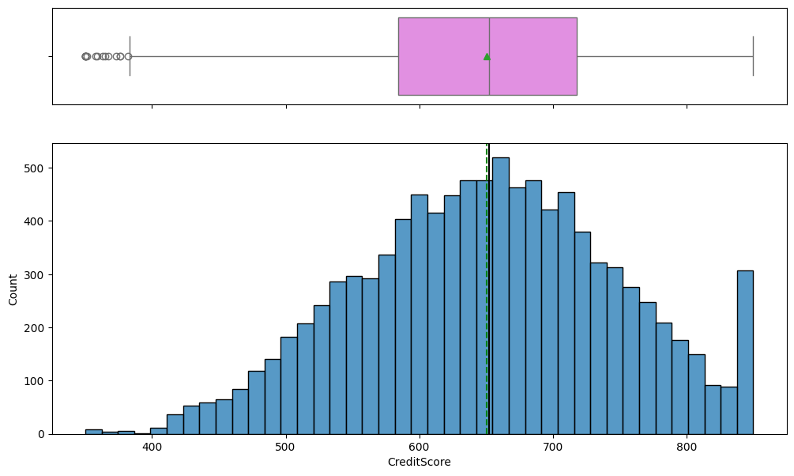

```python
# Visualize the distribution of the CreditScore
histogram_boxplot(data, 'CreditScore')
```

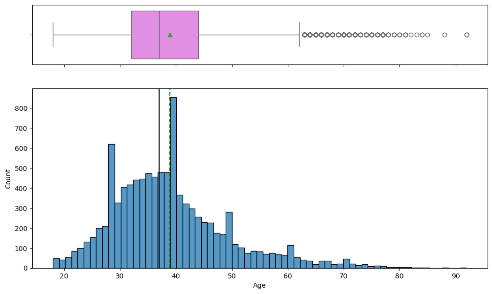

```python
# Visualize the distribution of the Age
histogram_boxplot(data, 'Age')
```

- The majority of bank customers are in their 30s and 40s, with a peak around the age of 40.
- There's a significant drop-off in customer count for ages above 50, suggesting fewer older customers.

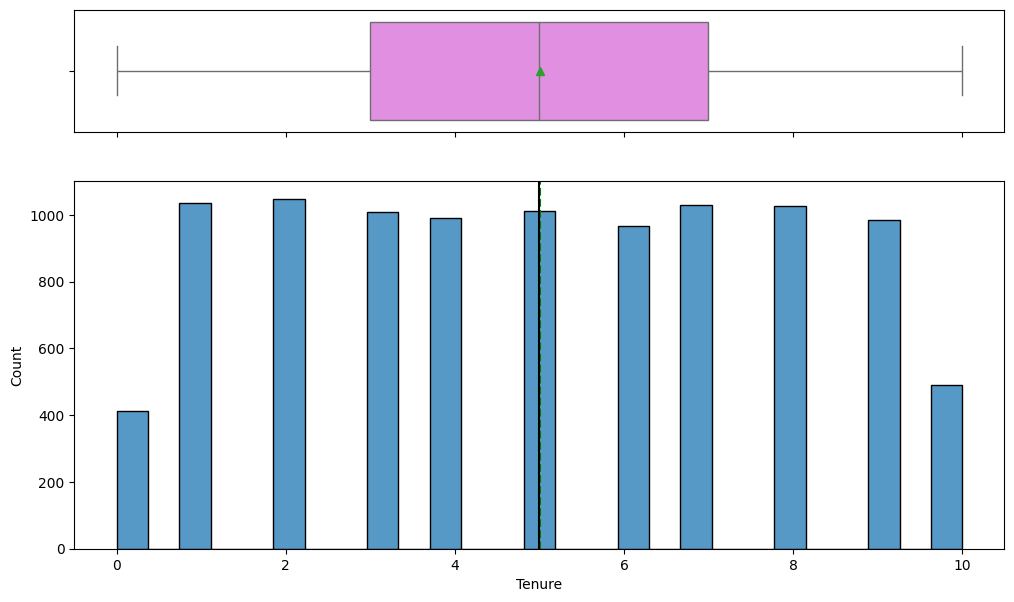

```python
# Visualize the distribution of the Tenure
histogram_boxplot(data, 'Tenure')
```

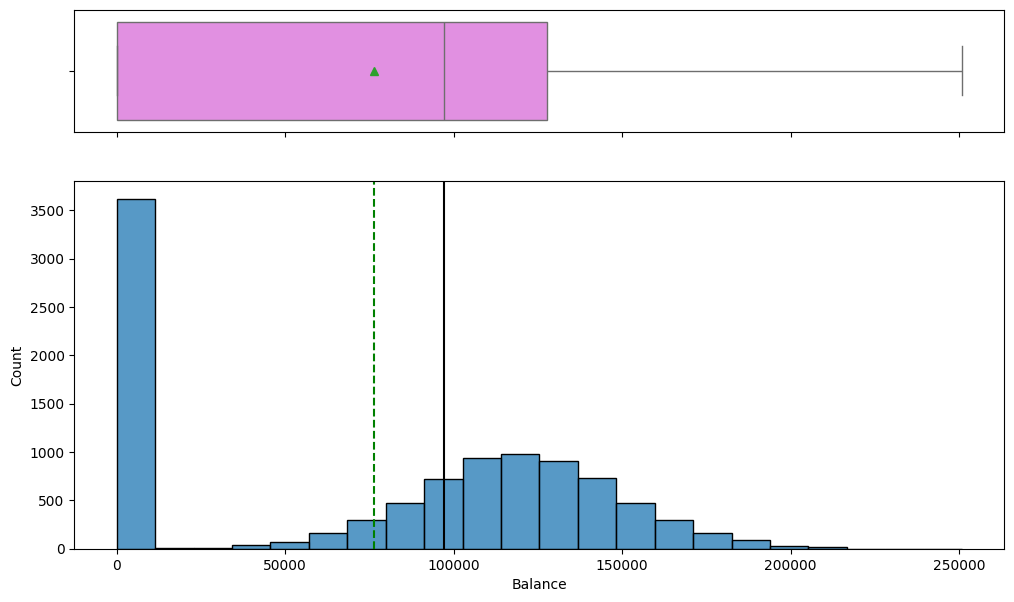

```python
# Visualize the distribution of the Balance
histogram_boxplot(data, 'Balance')
```

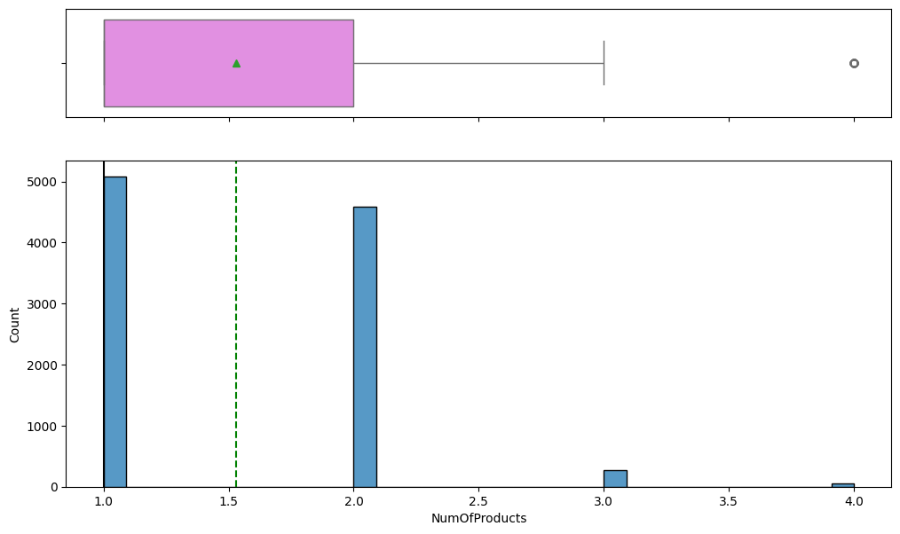

```python
# Visualize the distribution of the NumOfProducts
histogram_boxplot(data, 'NumOfProducts')
```

- The distribution of the number of products is highly concentrated around 1 and 2, with very few customers having 3 or 4 products.
- The mean is close to 1.5, indicating the majority of customers have fewer products, while a small outliers exist.

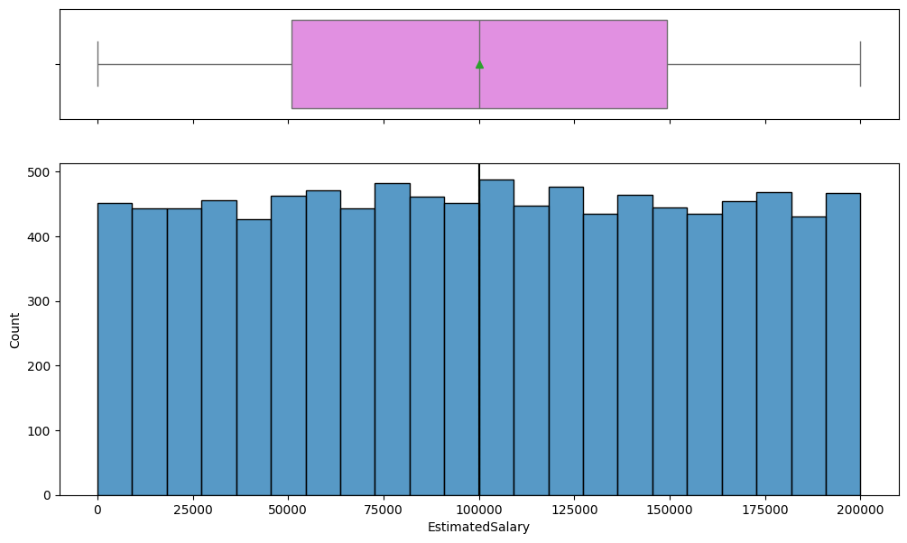

```python
# Visualize the distribution of the EstimatedSalary
histogram_boxplot(data, 'EstimatedSalary')
```

- The estimated salary of customers is **uniformly distributed**, indicating no significant bias toward any particular income range.
- The box plot shows a symmetric distribution with no apparent outliers, and the median is centered near 100,000.